# Activity and Ad Interest Analysis

## Introduction

This report explores the relationship between YouTube ad experiences and user interest. Data was collected via a short survey asking participants about ad frequency, types, and their level of interest.

## Plot 1: Number of entries over time

This line chart shows the number of survey entries recorded each day. The x-axis represents the date, and the y-axis shows the count of entries per day. The chart visualizes how participant activity varied over time, highlighting trends such as spikes in data collection or periods of low engagement

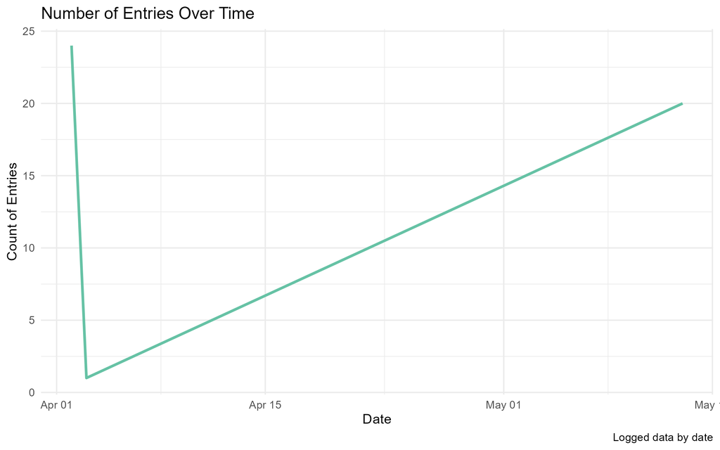

Number of entries plot

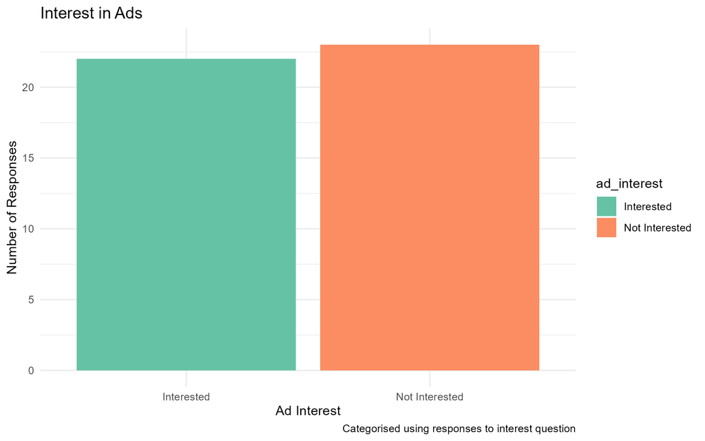

Ad interest Plot

## Plot 3: Ad Description Complexity Over Time

This scatter plot displays the 30 most detailed responses to the question ‘What type of ads did you see?’. The x-axis shows the date and time each response was submitted, and the y-axis represents the estimated word count of each response, calculated by counting spaces plus one. Each point represents a single entry, highlighting when participants gave longer and more complex answers.”

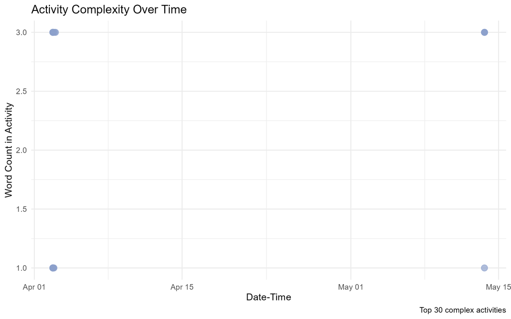

Word count plot